# Introduction

Archit Gubiligari | Ankit Gubiligari | Christine Park

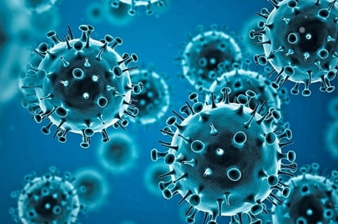

The Deadly Covid 19 Virus in Microscopic Form

Looking at our past couple of years, a lot has changed due to COVID-19 Pandemic that has taken the world by storm. Mask mandates and little to no social gatherings caused the world to fall into a depression that is still reaping the world today. Many mistakes were made in the world by not taking action quickly enough to combat this virus and the citizens often were ignorant or did not fully understand the severity of this pandemic situation. With these datasets and our analysis, we hope to provide more education to the public about the Virus and our resources to combat it as long as COVID-19 is still present.

Guiding Questions:

1. How did the population of people in the US with COVID increase as the pandemic continued and resources declined?
2. What was the location with the highest covid infected population in 2020?
3. What were the average number of hospitalizations in 2020 in relationship to vaccination rate?
4. In which location was the covid fatality rate the highest?

Dataset:

This dataset is data that is derived from the organization Our World in Data and their data on covid 19 and consists of state by state observations about Covid 19 vaccinations around the United States. Using this data, we can answer the questions regarding vaccinations and hospitalizations. There are 33812 observations and 16 features in this dataset and the question that can be answered is “What is the correlation between vaccination rates and hospitalization rates between US States “?

Some concerns about this dataset include many outliers and people that got covid and were asymptomatic or did not seek treatment.